# satisfying R solution

Hannah McSorley

16/03/2020

This is a copy of the GitHub issue thred discussion I had with my data science teacher (but mostly with myself) about some thesis coding that I was stuck on. I’ve basically copy-and-pasted the discussion here, for you to read as an html page.

## Initial post:

Hello @firasm 👋 *I’ll also tag the TAs in case they have suggestions* 😄 @matthewconnell @andrealee011 @yuliaUU

Here is a summary of the MSc coding challenge I’m working on (this is for my thesis work):

I have two dataframes (df1 is considerably longer than df2) and their key variables are:

```
df1:
  DateTime  # continuous time series at 10-min intervals
  Trip      # Trip = c(1:23) where each Trip (field-trip) identified a specific time span (interval)
  Height    # key variable that was logged at 10 minute intervals
  Site      # Six unique sites
```

```
df2:
  Site       # same as above
  Trip       # same as above
  Sample     # unique identifier for collected item / corresponds to 'obs_height'
  obs_height # singular observed value that corresponds to "df1$Height"
```

**R goal:** Create a new variable (column) in `df2` that identifies the `DateTime` at which each `Sample` was obtained based on matching `obs_height` to `Height`.

My approach was something like: * For each `Sample` at each `Site`, use the `Trip` ID to isolate the `DateTime` that corresponds to the first occurrence at which `df1$Height` was equal to or greater than `df2$obs_height`.

When I had complete 4 field trips, I accomplished this task in a *really horrible way* by subsetting each of df1 and df2 for each Site and each Trip and running a for loop on each subset dataframe (for this example I’ll stick with using “df1” and “df2” but note that these were subsets in practice… so ugly, I know ☹️):

```
# create an empty vector to hold the outputs from the loop
occur_index <- vector(length = nrow(df2))
# isolate the vector of Datetimes for later extraction
DT<- df1$DateTime

# find the index for the first occurrence of 'Height' equaling or exceeding 'obs_height'
for (i in seq_along(df2$Sample)) {
  occur_index[i] <- purrr::detect_index(df1$Height, ~ .x >= df2$obs_height[i], .dir = "forward")
}

# then create the new df2 column with corresponding DateTime from df1
df2 %>%
  mutate(sample_time = DT[occur_index])
```

This hacky method worked OK when I had fewer trips, but it was a horrible mess of subset dataframes and copy and paste. It’s terrible to look at and it’s not reproducible.

🙏 I am sure there’s a better way!!!

- I think that I should be able to use the `Trip` variable (essentially a span of DateTime) to narrow down df1 into more manageable sections to work on (but I’m not sure how).
- I still need to use the values in `df2$obs_height` to locate the first occurrence at which `df1$Height >= df2$obs_height` in order to extract corresponding `df1$DateTime`…. I’m just not sure what the best method is.

I feel like there might be some option using `dplyr::case_when()` or `tidyr::nest()`, or one of the `purrr::map*()` functions… but, I dunno. 🤷‍♀

I don’t need the final code to be impressive or groundbreaking, but I would like to create something reproducible and logical.

Any help or suggestions will be greatly appreciated!

Thanks in advance 😅

Hannah

## His Reply:

I posted your issue to my other (much larger) class in MDS. Here’s one reply (pasting as-is):

There is some missing info (relationship between Height and obs_height are there missing rows in either df?) which makes it hard to help this person, but here is my take:

- group in each df by Site & Trip, this should result in corresponding groups in the two df’s that are hopefully of the same number of rows (several rows per Site + Trip, depending on how many observations were registered each time).
- We are now left with the problem of matching the individual observations for each Site + Trip in each df, and this is where the missing info is a problem – But, assuming the measurement method is consistent within each df, which would mean that the relative relationship between the measurements of Height and obs_height (again per trip+site) should be consistent between the two DF:
- A possible method to matching the Height to obs_height (again per trip+site) by ranking the internal relative size, and then match the two sets by that ranking, again only assuming that the internal relative relationship is maintained. *For example, a set of measurements that goes something like [8,5,6,4,12] and another set would be [26, 40, 25.5, 8, 12], the corresponding ranks would be [R_4, R_2, R_3, R_1, R_5] and [r_4, r_5, r_3, r_1, r_2] and then organise the rows such that R_i = r_i.
  - This method won’t work if there are missing rows

### My reply

Thank you.

I suppose my initial inquiry wasn’t quite clear enough, I’ll try to clarify and provide more details.

The plot below shows what I’m after (for each of the six sites), but I achieved the matching in a horrible way that was not reproducible.

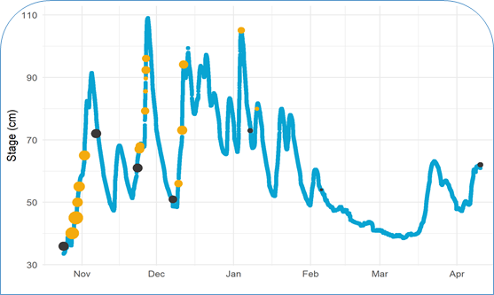

In this plot:

- the blue line is `df1$Height` (river stage)
- x = is `df1$DateTime`, y = `df1$Height`
- the points are samples from df2
  - for each point (sample), the DateTime of collection was extracted from df1 based on indexing the first occurrence at which `df1$Height >= df$2obs_height` (for each ‘trip’, for each ‘site’)

I wonder if this may require for loops (or possibly nested loops)? I thought there might be a way to achieve it with case_when() or a map or apply function…

essentially, I think I need to:

- group by trip, site and sample
  - e.g. *for each trip (1:23)… for each site (unique name)… and for each sample within those groupings…
- pass over df1 (by groups) and find the first instance at which ‘Height’ equaled or exceeded the ‘obs_height’ value that corresponded to each sample.

I know this is a complex issue, I hope I’ve explained it better here than previously.

### My reply to my own reply:

I solved it!! I think it was helpful to just explain what i was trying to do. I woke up this morning and though about how I ultimately just want to join these two dataframes, and worked back from that and got it!

I made it so much more complicated than it had to be. Below is a simplified summary of what I ended up doing. Basically, I grouped each dataframe by the key variables, then I used dplyr::distinct() to condense the long dataframe (that contained the desired DateTimes) so that only the first occurrence of the matching variable ‘height’ was listed (because there were multiple instances of the same value in sequence), then I did a left_join() and that merged the two dataframes into one where each sample had a proper DateTime based on it’s matching ‘height’. Yay!

```
df1:
   DateTime : POSIXct
   trip        : factor w/ 23 levels
   site        : factor w/ 6 levels
   height      : num

df2:
   trip            : factor w/ 23 levels
   site            : factor w/ 6 levels
   sample         : num
   obs_height  : num

# group the shorter dataframe
# change matching variable to same name as df1
df2 %>%
   group_by(site, trip) %>%
       rename(height = obs_height)

# group longer dataframe with DateTime
# use 'distinct' to compress
# keep all other variables in the dataframe
# join with df2
result <- df1 %>%
   group_by(site, trip) %>%
       dplyr::distinct(height, .keep_all = TRUE) %>%
   left_join(df2, by = c("site", "trip", "height"))
```

From there, I could manipulate the result dataframe as I needed, but this achieved all the matching i needed to do. And it was infinitely better than the janky code I’d written before, didn’t involve uneccessary subsetting and is reproducible and logical. I’m stoked.

Thank you for your willingness to help and for posing it to your other class! 👍 Hannah